# (Factors affecting Borrower interest rate?)

## by (Amira Salama)

## Investigation Overview

> Investigating factors affecting borrower’s APR or interest rate, and loan’s outcome status

## Dataset Overview

> Prosper Marketplace is America's first peer-to-peer lending marketplace, with over $7 billion in funded loans, Borrowers request personal loans on Prosper and investors (individual or institutional) can fund anywhere from USD 2000 to USD 40000 per loan request.

> Investors can consider borrowers’ credit scores, ratings, and histories and the category of the loan. Prosper handles the servicing of the loan and collects and distributes borrower payments and interest back to the loan investors.

## Interest Rate Ranges

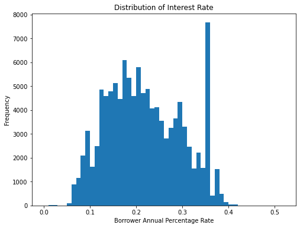

## Income Ranges Vs Interest rate and Amount

> The Most Accepted Income ranges are between 25k and 75k, the higher income range the higher the loan amount and the less rate applied on the loan.

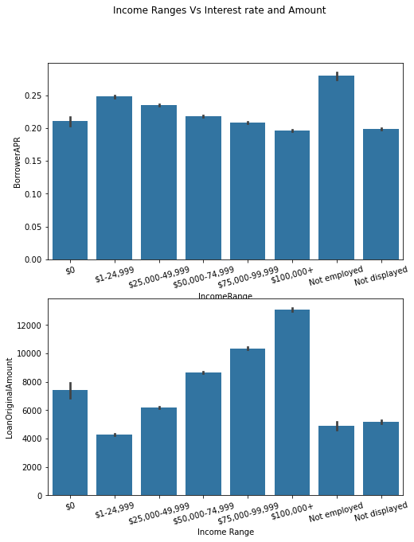

## Interest Rate Vs Credit Score Range

> The Credit Score Range is a three-digit number, typically between 300 and 850, designed to represent a borrower's credit risk, or the likelihood he/she will pay their bills on time, after plotting the relationship between interest rate and credit score range, a negative relationship was spotted.

> Higher Credit score Ranges are associated with less loan rate applied.the higher the score the more liable for a borrower to get the loan, above 70% of the scores are higher than 580 score which is the fair score or the accepted one.

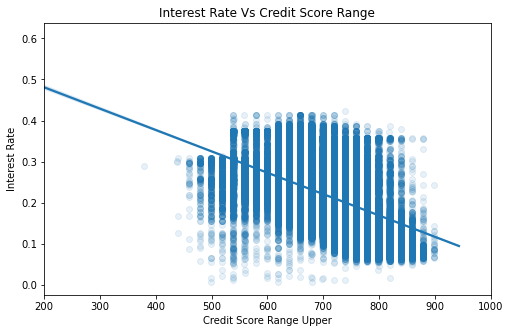

## Loan Amount Vs Interest Rate

> After that I wanted to investigate the relationship between the Interest rate and the loan amount, the scatterplot shows that there's a negative relationship between borrower APR (Interest Rate) and the Loan Original Amount, the higher the loan amount, the less the rate applied.

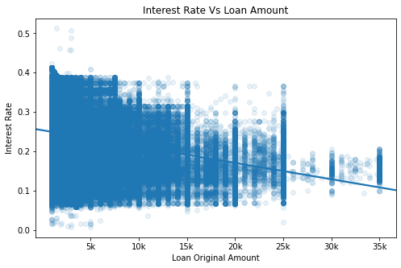

## Loan Status Vs Amount and income ranges

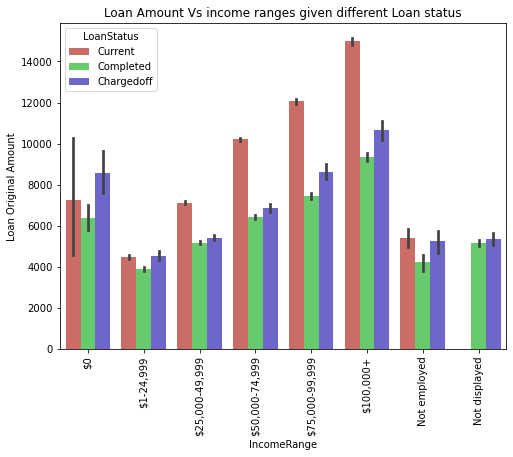

## Loan Amount Vs prosper score and what affects the loan Status

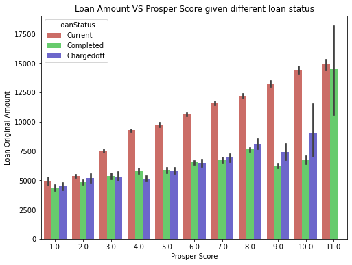